# Electric Vehicle Population Analysis: Washington State

### By: Niyant Patel, Neel Mokaria, Bhrugu Bhatt, Armin Moattari

#### CMSC320 Final Project - Fall2025

### Contributions

- **Bhrugu Bhatt:**
  - **C:** Conducted ANOVA tests for regional price differences.
  - **D:** Designed the KNN classifier for BEV vs. PHEV identification.
  - **E:** Optimized model training and handled test data analysis.
- **Niyant Patel:**
  - **C:** Performed Pearson Correlation analysis.
  - **D:** Linear Regression model for MSRP Prediction.
  - **F:** Analyzed pricing trends and residuals.
- **Armin Moattari:**
  - **D:** Implemented K-Means clustering for market segmentation.
  - **F:** Created visualizations for cluster profiles and geographic distribution.
  - **G:** Synthesized final market segmentation insights.
- **Neel Mokaria:**
  - **D:** Built the Random Forest classifier for CAFV eligibility prediction.
  - **E:** Engineered features using Label Encoding for categorical variables.
  - **F:** Analyzed feature importance rankings and policy implications.
1. Introduction
2. Preprocessing
3. Data Cleaning
4. Statistical Analysis
5. Machine Learning Analysis
   - **Part 1: EV Vehicle Type Classification (BEV vs PHEV) - KNN**
   - **Part 2: CAFV Eligibility Prediction (Random Forest)**
   - **Part 3: MSRP Prediction (Regression)**
   - **Part 4: EV Market Segmentation using K-Means Clustering**
6. Final Conclusions: EV Market Analysis Synthesis

# Introduction

Electric vehicles (EVs) are transforming the automotive industry, with adoption rates accelerating across the United States. Washington State, home to over 269,000 registered EVs, provides a rich dataset for understanding EV market dynamics, policy effectiveness, and consumer behavior.

### Why This Matters

- Washington's Clean Alternative Fuel Vehicle (CAFV) program offers significant incentives for eligible EVs
- Understanding what determines eligibility, pricing, and vehicle types helps consumers make informed decisions
- Policy makers can evaluate the effectiveness of range-based eligibility criteria

### Research Questions

This analysis explores three interconnected questions:

1. **Vehicle Classification**: Can we accurately predict whether an EV is a Battery Electric Vehicle (BEV) or Plug-in Hybrid (PHEV) based on its characteristics?
2. **Policy Eligibility**: What factors determine CAFV eligibility, and can we predict which vehicles qualify for incentives?
3. **Price Prediction**: What vehicle attributes most influence base MSRP?

### Data Source

We use the [Electric Vehicle Population Data](https://catalog.data.gov/dataset/electric-vehicle-population-data) from Washington State Department of Licensing, containing 269,673 registered EVs.

# Preprocessing

```python
## Libraries && Dependencies
import pandas as pd
import numpy as np
import matplotlib.pyplot as plt
import seaborn as sns
from datetime import datetime
from scipy.stats import chisquare, f_oneway, ttest_ind
```

```python
# Load the Electric Vehicle Population Data
# df = pd.read_csv("Electric_Vehicle_Population_Data.csv")
df = pd.read_csv("/content/Electric_Vehicle_Population_Data.csv")
print(f"Shape: {df.shape}")
```

```
Shape: (269673, 17)
```

```python
df.head()
```

|  | VIN (1-10) | County | City | State | Postal Code | Model Year | Make | Model | Electric Vehicle Type | Clean Alternative Fuel Vehicle (CAFV) Eligibility | Electric Range | Base MSRP | Legislative District | DOL Vehicle ID | Vehicle Location | Electric Utility | 2020 Census Tract |
| --- | --- | --- | --- | --- | --- | --- | --- | --- | --- | --- | --- | --- | --- | --- | --- | --- | --- |
| 0 | 3C3CFFGE1G | Yakima | Yakima | WA | 98908.0 | 2016 | FIAT | 500 | Battery Electric Vehicle (BEV) | Clean Alternative Fuel Vehicle Eligible | 84.0 | 0.0 | 14.0 | 180778377 | POINT (-120.60199 46.59817) | PACIFICORP | 5.307700e+10 |
| 1 | WP0AB2Y16L | King | Auburn | WA | 98092.0 | 2020 | PORSCHE | TAYCAN | Battery Electric Vehicle (BEV) | Clean Alternative Fuel Vehicle Eligible | 203.0 | 0.0 | 47.0 | 277717723 | POINT (-122.18497 47.28825) | PUGET SOUND ENERGY INC\|\|CITY OF TACOMA - (WA) | 5.303303e+10 |
| 2 | 5YJ3E1EB2J | King | Seattle | WA | 98109.0 | 2018 | TESLA | MODEL 3 | Battery Electric Vehicle (BEV) | Clean Alternative Fuel Vehicle Eligible | 215.0 | 0.0 | 36.0 | 475865722 | POINT (-122.35022 47.63824) | CITY OF SEATTLE - (WA)\|CITY OF TACOMA - (WA) | 5.303301e+10 |
| 3 | 5YJYGDEF5L | King | Seattle | WA | 98125.0 | 2020 | TESLA | MODEL Y | Battery Electric Vehicle (BEV) | Clean Alternative Fuel Vehicle Eligible | 291.0 | 0.0 | 46.0 | 108837249 | POINT (-122.30253 47.72656) | CITY OF SEATTLE - (WA)\|CITY OF TACOMA - (WA) | 5.303300e+10 |
| 4 | 5YJXCBE22J | Thurston | Olympia | WA | 98501.0 | 2018 | TESLA | MODEL X | Battery Electric Vehicle (BEV) | Clean Alternative Fuel Vehicle Eligible | 238.0 | 0.0 | 22.0 | 259851259 | POINT (-122.89165 47.03954) | PUGET SOUND ENERGY INC | 5.306701e+10 |

```python
df.columns
```

```
Index(['VIN (1-10)', 'County', 'City', 'State', 'Postal Code', 'Model Year',
       'Make', 'Model', 'Electric Vehicle Type',
       'Clean Alternative Fuel Vehicle (CAFV) Eligibility', 'Electric Range',
       'Base MSRP', 'Legislative District', 'DOL Vehicle ID',
       'Vehicle Location', 'Electric Utility', '2020 Census Tract'],
      dtype='object')
```

The dataset has 17 columns including vehicle identification, location data, specifications, and administrative fields. Understanding column names is essential for selecting relevant features and planning data transformations.

```python
df.dtypes
```

|  | 0 |
| --- | --- |
| VIN (1-10) | object |
| County | object |
| City | object |
| State | object |
| Postal Code | float64 |
| Model Year | int64 |
| Make | object |
| Model | object |
| Electric Vehicle Type | object |
| Clean Alternative Fuel Vehicle (CAFV) Eligibility | object |
| Electric Range | float64 |
| Base MSRP | float64 |
| Legislative District | float64 |
| DOL Vehicle ID | int64 |
| Vehicle Location | object |
| Electric Utility | object |
| 2020 Census Tract | float64 |

**dtype:** object

```python
df.isnull().sum()
```

|  | 0 |
| --- | --- |
| VIN (1-10) | 0 |
| County | 11 |
| City | 11 |
| State | 0 |
| Postal Code | 11 |
| Model Year | 0 |
| Make | 0 |
| Model | 0 |
| Electric Vehicle Type | 0 |
| Clean Alternative Fuel Vehicle (CAFV) Eligibility | 0 |
| Electric Range | 4 |
| Base MSRP | 4 |
| Legislative District | 664 |
| DOL Vehicle ID | 0 |
| Vehicle Location | 89 |
| Electric Utility | 11 |
| 2020 Census Tract | 11 |

**dtype:** int64

```python
df.info()
```

```
<class 'pandas.core.frame.DataFrame'>
RangeIndex: 269673 entries, 0 to 269672
Data columns (total 17 columns):
 #   Column                                             Non-Null Count   Dtype
---  ------                                             --------------   -----
 0   VIN (1-10)                                         269673 non-null  object
 1   County                                             269662 non-null  object
 2   City                                               269662 non-null  object
 3   State                                              269673 non-null  object
 4   Postal Code                                        269662 non-null  float64
 5   Model Year                                         269673 non-null  int64
 6   Make                                               269673 non-null  object
 7   Model                                              269673 non-null  object
 8   Electric Vehicle Type                              269673 non-null  object
 9   Clean Alternative Fuel Vehicle (CAFV) Eligibility  269673 non-null  object
 10  Electric Range                                     269669 non-null  float64
 11  Base MSRP                                          269669 non-null  float64
 12  Legislative District                               269009 non-null  float64
 13  DOL Vehicle ID                                     269673 non-null  int64
 14  Vehicle Location                                   269584 non-null  object
 15  Electric Utility                                   269662 non-null  object
 16  2020 Census Tract                                  269662 non-null  float64
dtypes: float64(5), int64(2), object(10)
memory usage: 35.0+ MB
```

```python
print(f"Number of duplicate rows: {df.duplicated().sum()}")

# Check duplicate VINs
if 'VIN (1-10)' in df.columns:
    print(f"Number of duplicate VINs: {df['VIN (1-10)'].duplicated().sum()}")
```

```
Number of duplicate rows: 0
Number of duplicate VINs: 253418
```

```python
df.describe()
```

|  | Postal Code | Model Year | Electric Range | Base MSRP | Legislative District | DOL Vehicle ID | 2020 Census Tract |
| --- | --- | --- | --- | --- | --- | --- | --- |
| count | 269662.000000 | 269673.000000 | 269669.000000 | 269669.000000 | 269009.000000 | 2.696730e+05 | 2.696620e+05 |
| mean | 98174.302260 | 2021.925832 | 40.751692 | 663.101079 | 28.851436 | 2.434417e+08 | 5.297165e+10 |
| std | 2590.609215 | 3.050066 | 79.604176 | 6790.627969 | 14.894449 | 6.461834e+07 | 1.632722e+09 |
| min | 1030.000000 | 1999.000000 | 0.000000 | 0.000000 | 1.000000 | 4.385000e+03 | 1.001020e+09 |
| 25% | 98052.000000 | 2021.000000 | 0.000000 | 0.000000 | 17.000000 | 2.190569e+08 | 5.303301e+10 |
| 50% | 98133.000000 | 2023.000000 | 0.000000 | 0.000000 | 32.000000 | 2.610981e+08 | 5.303303e+10 |
| 75% | 98382.000000 | 2024.000000 | 33.000000 | 0.000000 | 42.000000 | 2.768459e+08 | 5.305307e+10 |
| max | 99577.000000 | 2026.000000 | 337.000000 | 845000.000000 | 49.000000 | 4.791150e+08 | 6.601095e+10 |

EV Car Model Year ranges from 1999-2026, Electric Range from 0-337 miles, and Base MSRP from $0-$845,000. The summary statistics reveal data distributions and potential issues like zero values that may need investigation.

# Data Cleaning

```python
df = df.dropna()
print(f"Shape after removing missing values: {df.shape}")
print(f"Missing values remaining: {df.isnull().sum().sum()}")
```

```
Shape after removing missing values: (268927, 17)
Missing values remaining: 0
```

```python
# Convert data types for proper analysis
df['Model Year'] = df['Model Year'].astype(int)
df['Electric Range'] = pd.to_numeric(df['Electric Range'], errors='coerce')
df['Base MSRP'] = pd.to_numeric(df['Base MSRP'], errors='coerce')
df['Postal Code'] = df['Postal Code'].astype(str)
print("Data types after conversion:")
print(df.dtypes)
```

```
Data types after conversion:
VIN (1-10)                                            object
County                                                object
City                                                  object
State                                                 object
Postal Code                                           object
Model Year                                             int64
Make                                                  object
Model                                                 object
Electric Vehicle Type                                 object
Clean Alternative Fuel Vehicle (CAFV) Eligibility     object
Electric Range                                       float64
Base MSRP                                            float64
Legislative District                                 float64
DOL Vehicle ID                                         int64
Vehicle Location                                      object
Electric Utility                                      object
2020 Census Tract                                    float64
dtype: object
```

Now Converting EV Model Year to int, Electric Range and Base MSRP to numeric, and Postal Code to string ensures correct data types for calculations. Proper data types prevent errors and enable accurate mathematical operations on numeric fields.

```python
# Extract latitude and longitude from Vehicle Location
df[['Longitude', 'Latitude']] = df['Vehicle Location'].str.extract(r'POINT \(([-\d.]+) ([-\d.]+)\)')
df['Longitude'] = pd.to_numeric(df['Longitude'], errors='coerce')
df['Latitude'] = pd.to_numeric(df['Latitude'], errors='coerce')
print("Sample coordinates:")
print(df[['Vehicle Location', 'Longitude', 'Latitude']].head())
```

```
Sample coordinates:
              Vehicle Location  Longitude  Latitude
0  POINT (-120.60199 46.59817) -120.60199  46.59817
1  POINT (-122.18497 47.28825) -122.18497  47.28825
2  POINT (-122.35022 47.63824) -122.35022  47.63824
3  POINT (-122.30253 47.72656) -122.30253  47.72656
4  POINT (-122.89165 47.03954) -122.89165  47.03954
```

Extracting longitude and latitude from the POINT format creates separate numeric columns for spatial coordinates. This enables geographic analysis like mapping vehicle density by location and analyzing regional adoption patterns.

```python
# Clean and standardize categorical variables
df['Make'] = df['Make'].str.strip().str.upper()
print("Electric Vehicle Type distribution:")
print(df['Electric Vehicle Type'].value_counts())
print("\nCAFV Eligibility distribution:")
print(df['Clean Alternative Fuel Vehicle (CAFV) Eligibility'].value_counts())
print("\nTop 10 Makes:")
print(df['Make'].value_counts().head(10))
```

```
Electric Vehicle Type distribution:
Electric Vehicle Type
Battery Electric Vehicle (BEV)            214577
Plug-in Hybrid Electric Vehicle (PHEV)     54350
Name: count, dtype: int64

CAFV Eligibility distribution:
Clean Alternative Fuel Vehicle (CAFV) Eligibility
Eligibility unknown as battery range has not been researched    168280
Clean Alternative Fuel Vehicle Eligible                          76530
Not eligible due to low battery range                            24117
Name: count, dtype: int64

Top 10 Makes:
Make
TESLA         110296
CHEVROLET      19064
NISSAN         16087
FORD           14709
KIA            13461
TOYOTA         11106
BMW            10996
HYUNDAI         9587
RIVIAN          8320
VOLKSWAGEN      7315
Name: count, dtype: int64
```

This Data distributions reveal the proportion of BEV vs PHEV vehicles, CAFV eligibility status, and dominant manufacturers like Tesla. Understanding categorical distributions helps identify trends and guides analysis questions about vehicle types and market share.

```python
# Identify outliers in Electric Range using IQR and Extereme Z-Score method
Q1 = df['Electric Range'].quantile(0.25)
Q3 = df['Electric Range'].quantile(0.75)
IQR = Q3 - Q1
lower_bound = Q1 - 1.5 * IQR
upper_bound = Q3 + 1.5 * IQR
outliers = ((df['Electric Range'] < lower_bound) | (df['Electric Range'] > upper_bound)).sum()
print(f"Electric Range - Q1: {Q1}, Q3: {Q3}, IQR: {IQR}")
print(f"Bounds: [{lower_bound}, {upper_bound}]")
print(f"Number of outliers: {outliers}")
```

```
Electric Range - Q1: 0.0, Q3: 33.0, IQR: 33.0
Bounds: [-49.5, 82.5]
Number of outliers: 43227
```

The Z-score using The IQR method identifies outliers in Electric Range that fall outside typical values. We document but keep these outliers because they represent valid high-performance EVs rather than data errors.

```python
# Displaying final clean dataset summary
print(f"Total rows: {len(df)}")
print(f"Total columns: {len(df.columns)}")
print(f"Missing values: {df.isnull().sum().sum()}")
print("\nFinal dataset:")
df.head()
```

```
Total rows: 268927
Total columns: 19
Missing values: 0

Final dataset:
```

|  | VIN (1-10) | County | City | State | Postal Code | Model Year | Make | Model | Electric Vehicle Type | Clean Alternative Fuel Vehicle (CAFV) Eligibility | Electric Range | Base MSRP | Legislative District | DOL Vehicle ID | Vehicle Location | Electric Utility | 2020 Census Tract | Longitude | Latitude |
| --- | --- | --- | --- | --- | --- | --- | --- | --- | --- | --- | --- | --- | --- | --- | --- | --- | --- | --- | --- |
| 0 | 3C3CFFGE1G | Yakima | Yakima | WA | 98908.0 | 2016 | FIAT | 500 | Battery Electric Vehicle (BEV) | Clean Alternative Fuel Vehicle Eligible | 84.0 | 0.0 | 14.0 | 180778377 | POINT (-120.60199 46.59817) | PACIFICORP | 5.307700e+10 | -120.60199 | 46.59817 |
| 1 | WP0AB2Y16L | King | Auburn | WA | 98092.0 | 2020 | PORSCHE | TAYCAN | Battery Electric Vehicle (BEV) | Clean Alternative Fuel Vehicle Eligible | 203.0 | 0.0 | 47.0 | 277717723 | POINT (-122.18497 47.28825) | PUGET SOUND ENERGY INC\|\|CITY OF TACOMA - (WA) | 5.303303e+10 | -122.18497 | 47.28825 |
| 2 | 5YJ3E1EB2J | King | Seattle | WA | 98109.0 | 2018 | TESLA | MODEL 3 | Battery Electric Vehicle (BEV) | Clean Alternative Fuel Vehicle Eligible | 215.0 | 0.0 | 36.0 | 475865722 | POINT (-122.35022 47.63824) | CITY OF SEATTLE - (WA)\|CITY OF TACOMA - (WA) | 5.303301e+10 | -122.35022 | 47.63824 |
| 3 | 5YJYGDEF5L | King | Seattle | WA | 98125.0 | 2020 | TESLA | MODEL Y | Battery Electric Vehicle (BEV) | Clean Alternative Fuel Vehicle Eligible | 291.0 | 0.0 | 46.0 | 108837249 | POINT (-122.30253 47.72656) | CITY OF SEATTLE - (WA)\|CITY OF TACOMA - (WA) | 5.303300e+10 | -122.30253 | 47.72656 |
| 4 | 5YJXCBE22J | Thurston | Olympia | WA | 98501.0 | 2018 | TESLA | MODEL X | Battery Electric Vehicle (BEV) | Clean Alternative Fuel Vehicle Eligible | 238.0 | 0.0 | 22.0 | 259851259 | POINT (-122.89165 47.03954) | PUGET SOUND ENERGY INC | 5.306701e+10 | -122.89165 | 47.03954 |

```python
# Save cleaned dataset for analysis
df.to_csv('EV_Data_Cleaned.csv', index=False)
print("Cleaned dataset saved as 'EV_Data_Cleaned.csv'")
```

```
Cleaned dataset saved as 'EV_Data_Cleaned.csv'
```

# Pearson Correlation Coefficient

**Correlation Between Model Year and Electric Range:**

The value of -0.29 means there is a weak inverse relationship: as Model Year increases, Electric Range tends to decrease slightly. This result is somewhat unexpected given technological improvements over time, possibly reflecting dataset-specific factors like inclusion of newer models with shorter ranges, or market shifts towards more diverse vehicle types. The following scatter plot visualizes this relationship, illustrating the spread and trend between Model Year and Electric Range:

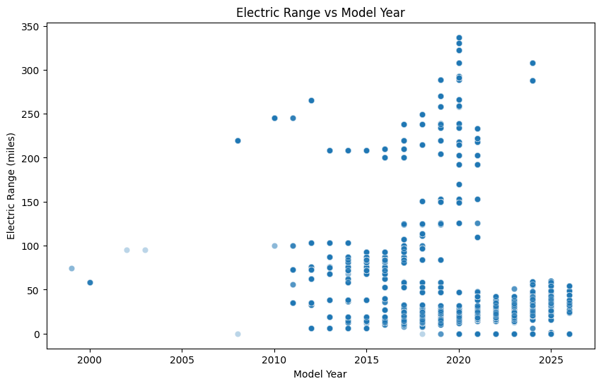

```python
plt.figure(figsize=(10,6))
sns.scatterplot(x=df['Model Year'], y=df['Electric Range'], alpha=0.3)
plt.title('Electric Range vs Model Year')
plt.xlabel('Model Year')
plt.ylabel('Electric Range (miles)')
plt.show()
```

**Conclusion:**

This weak negative correlation indicates no clear trend of increasing electric range with newer vehicle models in this dataset. The findings suggest further analysis is needed possibly controlling for vehicle type or manufacturer to better understand EV range trends over time.

# ANOVA Test

**Differences in Base MSRP by County:**

The statistical method used to reach the conclusion about differences in base MSRP by county is one-way ANOVA on filtered data for the top five counties.

```
Filtered dataset shape: (3122, 19)
Percentage of original data: 1.2%
Filtered mean MSRP: $57087.32
Filtered median MSRP: $55700.00
Filtered range: $31950.00 - $845000.00
Top 5 counties by EV count (filtered): ['King', 'Snohomish', 'Pierce', 'Clark', 'Kitsap']

Filtered ANOVA F-statistic: 0.932
Filtered P-value: 4.44e-01
```

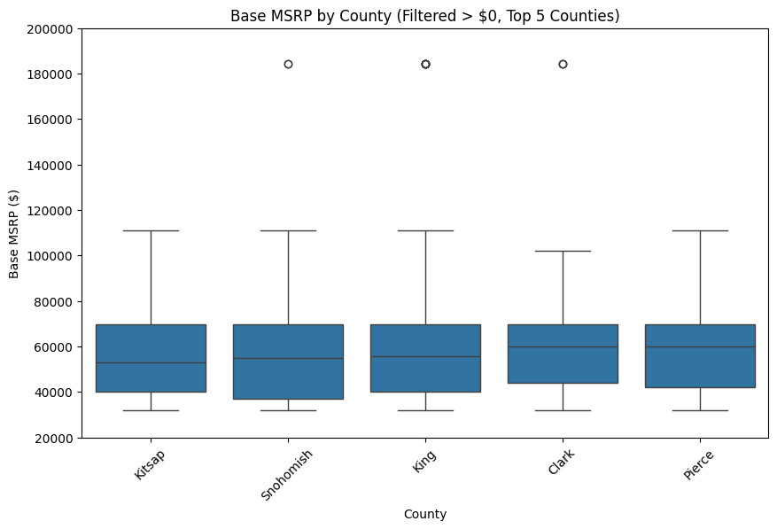

```
Number of vehicles with MSRP > $200,000 (omitted from plot due to y-limit): 1
```

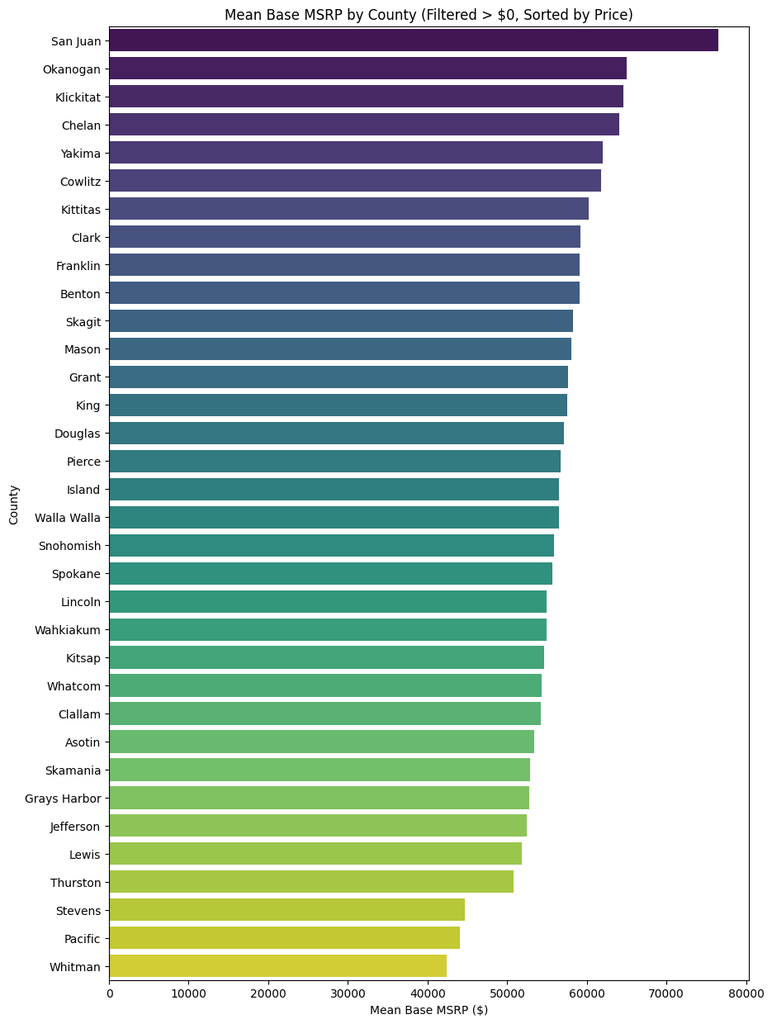

```python
# Filter for vehicles with reported MSRP (> $0) for price analysis
df_msrp = df[df['Base MSRP'] > 0].copy()
print(f"Filtered dataset shape: {df_msrp.shape}")
print(f"Percentage of original data: {len(df_msrp)/len(df)*100:.1f}%")
print(f"Filtered mean MSRP: ${df_msrp['Base MSRP'].mean():.2f}")
print(f"Filtered median MSRP: ${df_msrp['Base MSRP'].median():.2f}")
print(f"Filtered range: ${df_msrp['Base MSRP'].min():.2f} - ${df_msrp['Base MSRP'].max():.2f}")

# Update county analysis with filtered data (top 5 counties)
top_counties_filtered = df_msrp['County'].value_counts().head(5).index
print(f"Top 5 counties by EV count (filtered): {list(top_counties_filtered)}")

county_df_filtered = df_msrp[df_msrp['County'].isin(top_counties_filtered)]

# Perform ANOVA on filtered data (top 5 counties)
groups_filtered = [county_df_filtered[county_df_filtered['County'] == county]['Base MSRP'] for county in top_counties_filtered]
f_stat_filtered, p_value_filtered = f_oneway(*groups_filtered)
print(f"\nFiltered ANOVA F-statistic: {f_stat_filtered:.3f}")
print(f"Filtered P-value: {p_value_filtered:.2e}")

# Boxplot on filtered data (top 5 counties)
plt.figure(figsize=(10,6))
sns.boxplot(x='County', y='Base MSRP', data=county_df_filtered)
plt.title('Base MSRP by County (Filtered > $0, Top 5 Counties)')
plt.xlabel('County')
plt.ylabel('Base MSRP ($)')
plt.xticks(rotation=45)
plt.ylim(20000, 200000) # Upper & Lower Y-axis bounds
plt.show()

# Indicate outliers omitted
outliers_omitted = (county_df_filtered['Base MSRP'] > 200000).sum()
print(f"Number of vehicles with MSRP > $200,000 (omitted from plot due to y-limit): {outliers_omitted}")

# Bar chart for mean MSRP by all counties (filtered)
mean_msrp_filtered = df_msrp.groupby('County')['Base MSRP'].mean().sort_values(ascending=False)
plt.figure(figsize=(10,15))
sns.barplot(x=mean_msrp_filtered.values, y=mean_msrp_filtered.index, palette='viridis', hue=mean_msrp_filtered.index, legend=False)
plt.title('Mean Base MSRP by County (Filtered > $0, Sorted by Price)')
plt.xlabel('Mean Base MSRP ($)')
plt.ylabel('County')
plt.show()
```

**EV Distribution by Brand:**

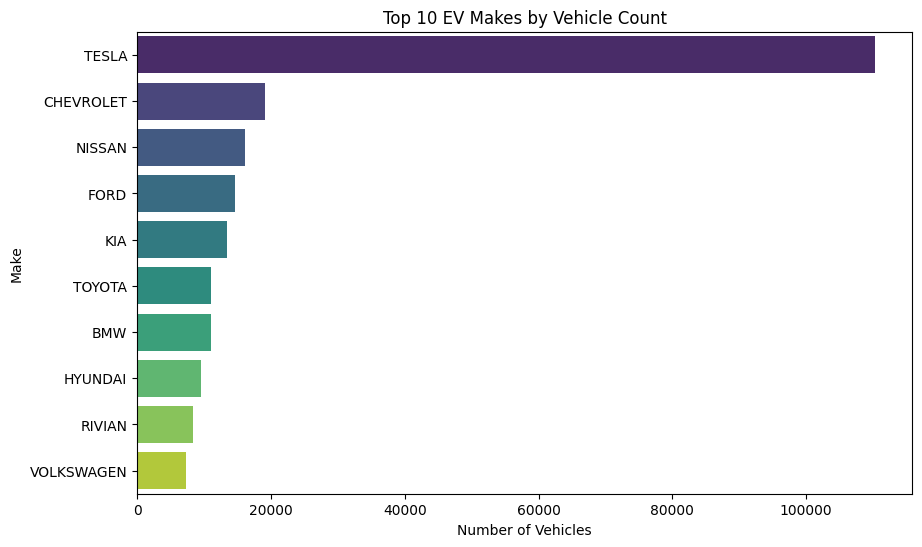

```
Chi-square test for uniform distribution among top 10 makes: chi2=396594.27, p=0.00e+00
```

```python
# Bar chart for EV distribution by brand
top_makes = df['Make'].value_counts().head(10)
plt.figure(figsize=(10,6))
sns.barplot(x=top_makes.values, y=top_makes.index, palette='viridis', hue=top_makes.index, legend=False)
plt.title('Top 10 EV Makes by Vehicle Count')
plt.xlabel('Number of Vehicles')
plt.ylabel('Make')
plt.show()

# Hypothesis testing: Chi-square goodness of fit test assuming uniform distribution
total_top = top_makes.sum()
expected_uniform = [total_top / 10] * 10
chi2_stat, p_value = chisquare(top_makes.values, expected_uniform)
print(f"Chi-square test for uniform distribution among top 10 makes: chi2={chi2_stat:.2f}, p={p_value:.2e}")
```

# Two-Sample T-Test

**Reason for choosing:**  
The Two-Sample T-Test was chosen because the goal is to determine if there is a statistically significant difference between the mean electric range of two independent groups: Battery Electric Vehicles (BEV) and Plug-in Hybrid Electric Vehicles (PHEV)

**Hypotheses**

1. Null Hypothesis: The mean electric range for BEVs is equal to the mean electric range for PHEVs
2. Alternative Hypothesis: The mean electric range for BEVs is greater than the mean electric range for PHEVs.

```
Mean Electric Range (BEV): 43.07 miles
Mean Electric Range (PHEV): 31.62 miles

Two-Sample T-Test (BEV vs. PHEV Electric Range):
T-statistic: 57.03
P-value (one-tailed, testing BEV > PHEV): 0.0000000000e+00
```

```
(0.0, 200.0)
```

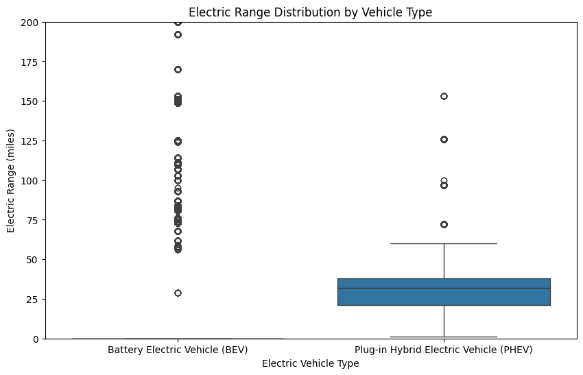

```python
df = pd.read_csv("/content/Electric_Vehicle_Population_Data.csv")

df = df.dropna()
df['Model Year'] = df['Model Year'].astype(int)
df['Electric Range'] = pd.to_numeric(df['Electric Range'], errors='coerce')
df['Base MSRP'] = pd.to_numeric(df['Base MSRP'], errors='coerce')
df['Postal Code'] = df['Postal Code'].astype(str)
df['Make'] = df['Make'].str.strip().str.upper()
df[['Longitude', 'Latitude']] = (
    df['Vehicle Location']
    .str.replace('POINT (', '', regex=False)
    .str.replace(')', '', regex=False)
    .str.split(' ', expand=True)
)
df['Longitude'] = pd.to_numeric(df['Longitude'], errors='coerce')
df['Latitude'] = pd.to_numeric(df['Latitude'], errors='coerce')
df = df.dropna(subset=['Longitude', 'Latitude'])

bev_range = df[df['Electric Vehicle Type'] == 'Battery Electric Vehicle (BEV)']['Electric Range']
phev_range = df[df['Electric Vehicle Type'] == 'Plug-in Hybrid Electric Vehicle (PHEV)']['Electric Range']

print(f"Mean Electric Range (BEV): {bev_range.mean():.2f} miles")
print(f"Mean Electric Range (PHEV): {phev_range.mean():.2f} miles")

t_stat, p_value = ttest_ind(bev_range, phev_range, equal_var=False, alternative='greater')

print(f"\nTwo-Sample T-Test (BEV vs. PHEV Electric Range):")
print(f"T-statistic: {t_stat:.2f}")
print(f"P-value (one-tailed, testing BEV > PHEV): {p_value:.10e}")

plt.figure(figsize=(10, 6))
sns.boxplot(x='Electric Vehicle Type', y='Electric Range', data=df)
plt.title('Electric Range Distribution by Vehicle Type')
plt.xlabel('Electric Vehicle Type')
plt.ylabel('Electric Range (miles)')
plt.ylim(0, 200)
```

**Conclusion**  
The analysis shows a highly statistically significant difference in electric range between the two vehicle types.

Since the p-value ($0.00e+00$) is much lower than the typical $\alpha$ level of $0.05$, we reject the null hypothesis ($H_0$). This confirms that Battery Electric Vehicles (BEVs) have a statistically significant and greater mean electric range than Plug-in Hybrid Electric Vehicles (PHEVs). This expected difference is due to BEVs relying solely on a larger battery, while PHEVs use a smaller battery for limited electric-only driving.

# Machine Learning Analysis

Having explored the basic structure and distributions in our EV dataset, we now turn to predictive modeling. We address three related questions that progress from fundamental vehicle characteristics to policy implications to economic factors.

Our analysis follows a logical flow:

- First, we classify vehicles by type (BEV vs PHEV) to understand fundamental distinctions
- Then, we predict CAFV eligibility, which depends on vehicle type among other factors
- Finally, we model pricing, which is influenced by both type and eligibility status

# Part 1: EV Vehicle Type Classification (BEV vs PHEV) - KNN

```python
# Machine Learning Libraries
from sklearn.neighbors import KNeighborsClassifier
from sklearn.ensemble import RandomForestClassifier
from sklearn.model_selection import train_test_split, GridSearchCV, cross_val_score, RandomizedSearchCV, StratifiedKFold
from sklearn.preprocessing import LabelEncoder, StandardScaler, label_binarize
from sklearn.metrics import (accuracy_score, classification_report, confusion_matrix,
                             precision_score, recall_score, f1_score, roc_auc_score,
                             roc_curve, ConfusionMatrixDisplay)
from sklearn.inspection import permutation_importance
from matplotlib.colors import ListedColormap
import warnings
warnings.filterwarnings('ignore')
```

## Motivation and Intuition

We chose to implement a K Nearest Neighbors (KNN) classifier for this analysis because of its intuitive approach to classification based on similarity. Our previous exploratory data analysis indicated that Battery Electric Vehicles (BEVs) and Plug in Hybrid Electric Vehicles (PHEVs) have distinct characteristics, particularly in terms of their Electric Range. The intuition behind using KNN is that vehicles with similar technical specifications, specifically Electric Range and Model Year, are likely to belong to the same category. By plotting these vehicles in a feature space, we expect to see clusters where BEVs (typically longer range) and PHEVs (typically shorter range) group together. KNN leverages this natural clustering by classifying a new vehicle based on the majority class of its nearest neighbors, making it an ideal, interpretable model for this binary classification task.

## Feature Engineering

```python
# 1. Prepare the Data
print("\n" + "="*50)
print("Starting Machine Learning Analysis")
print("="*50)

# Filter for relevant columns and drop missing values
ml_df = df[['Electric Vehicle Type', 'Electric Range', 'Model Year', 'Make']].dropna().copy()

# Filter for only BEV and PHEV (just in case there are others, though dataset seems to have these two)
ml_df = ml_df[ml_df['Electric Vehicle Type'].isin(['Battery Electric Vehicle (BEV)', 'Plug-in Hybrid Electric Vehicle (PHEV)'])]

# Encode Target Variable
# BEV = 0, PHEV = 1 (or vice versa, we'll use map for clarity)
type_mapping = {'Battery Electric Vehicle (BEV)': 0, 'Plug-in Hybrid Electric Vehicle (PHEV)': 1}
ml_df['Target'] = ml_df['Electric Vehicle Type'].map(type_mapping)

print(f"ML Dataset Shape: {ml_df.shape}")
print("Target Distribution:")
print(ml_df['Electric Vehicle Type'].value_counts())
```

```
==================================================
Starting Machine Learning Analysis
==================================================
ML Dataset Shape: (268927, 5)
Target Distribution:
Electric Vehicle Type
Battery Electric Vehicle (BEV)            214577
Plug-in Hybrid Electric Vehicle (PHEV)     54350
Name: count, dtype: int64
```

```python
# 2. Feature Engineering
# One-Hot Encoding for 'Make'
# We'll keep only top 10 makes to avoid high dimensionality
top_10_makes = ml_df['Make'].value_counts().head(10).index
ml_df['Make_Encoded'] = ml_df['Make'].apply(lambda x: x if x in top_10_makes else 'Other')

# Create dummy variables
make_dummies = pd.get_dummies(ml_df['Make_Encoded'], prefix='Make', drop_first=True) # drop_first to avoid dummy variable trap

# Combine features
# We will use Electric Range and Model Year as primary numerical features
X_numerical = ml_df[['Electric Range', 'Model Year']]

# Concatenate numerical and categorical features
# Note: For the decision boundary visualization later, we'll primarily focus on the 2 numerical features,
# but for the main model performance, we can include makes.
# Let's build two models: one with all features for performance, one with 2 features for visualization.
# For this tutorial, let's stick to the 2 numerical features for clear visualization and "Intro to ML" simplicity,
# as visualizing >2D decision boundaries is complex.
# However, 'Make' is a strong predictor. Let's use 2 features for the core demonstration of KNN logic and visualization.

print("\nUsing features: Electric Range, Model Year")
X = ml_df[['Electric Range', 'Model Year']].values
y = ml_df['Target'].values
```

```
Using features: Electric Range, Model Year
```

```python
# 3. Train/Test Split
# Split data into training and testing sets (80% train, 20% test)
X_train, X_test, y_train, y_test = train_test_split(X, y, test_size=0.2, random_state=42)

print(f"Training set size: {X_train.shape[0]}")
print(f"Testing set size: {X_test.shape[0]}")

# 4. Feature Scaling (Standardization)
# Essential for KNN because it calculates distances.
scaler = StandardScaler()
X_train_scaled = scaler.fit_transform(X_train)
X_test_scaled = scaler.transform(X_test)

print("\nFeatures scaled using StandardScaler (Mean=0, Variance=1)")
```

```
Training set size: 215141
Testing set size: 53786

Features scaled using StandardScaler (Mean=0, Variance=1)
```

## Machine Learning Model: K-Nearest Neighbors (KNN)

```python
# 5. Model Training
k = 5
knn = KNeighborsClassifier(n_neighbors=k)
knn.fit(X_train_scaled, y_train)

print(f"\nTraining KNN model with k={k}...")

# 6. Prediction and Evaluation
y_pred = knn.predict(X_test_scaled)

print("\n" + "-"*30)
print("Model Evaluation Metrics")
print("-"*30)
print(f"Accuracy: {accuracy_score(y_test, y_pred):.4f}")
print("\nClassification Report:")
print(classification_report(y_test, y_pred, target_names=['BEV', 'PHEV']))

# Confusion Matrix
cm = confusion_matrix(y_test, y_pred)
```

```
Training KNN model with k=5...

------------------------------
Model Evaluation Metrics
------------------------------
Accuracy: 0.9999

Classification Report:
              precision    recall  f1-score   support

         BEV       1.00      1.00      1.00     42989
        PHEV       1.00      1.00      1.00     10797

    accuracy                           1.00     53786
   macro avg       1.00      1.00      1.00     53786
weighted avg       1.00      1.00      1.00     53786
```

## Visualization

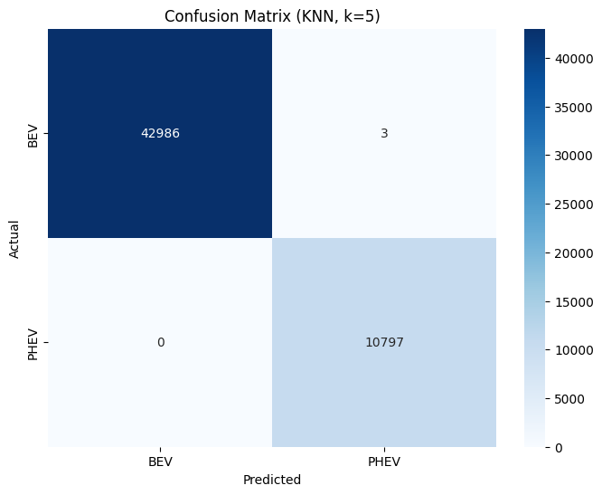

```
Generating Decision Boundary Plot...
```

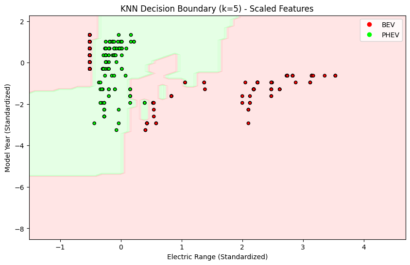

```python
# 7. Visualization: Confusion Matrix
plt.figure(figsize=(8, 6))
sns.heatmap(cm, annot=True, fmt='d', cmap='Blues', xticklabels=['BEV', 'PHEV'], yticklabels=['BEV', 'PHEV'])
plt.title(f'Confusion Matrix (KNN, k={k})')
plt.ylabel('Actual')
plt.xlabel('Predicted')
plt.show()

# 8. Visualization: Decision Boundary
# We need to create a meshgrid covering the feature space
print("\nGenerating Decision Boundary Plot...")

# Define bounds for the meshgrid
x_min, x_max = X_train_scaled[:, 0].min() - 1, X_train_scaled[:, 0].max() + 1
y_min, y_max = X_train_scaled[:, 1].min() - 1, X_train_scaled[:, 1].max() + 1
xx, yy = np.meshgrid(np.arange(x_min, x_max, 0.1),
                     np.arange(y_min, y_max, 0.1))

# Predict for each point in the meshgrid
Z = knn.predict(np.c_[xx.ravel(), yy.ravel()])
Z = Z.reshape(xx.shape)

# Create color map
cmap_light = ListedColormap(['#FFAAAA', '#AAFFAA'])
cmap_bold = ListedColormap(['#FF0000', '#00FF00'])

plt.figure(figsize=(10, 6))
plt.contourf(xx, yy, Z, cmap=cmap_light, alpha=0.3)

# Plot also the training points (subset to avoid overcrowding)
# We'll plot a random sample of 500 points
sample_indices = np.random.choice(len(X_train_scaled), 500, replace=False)
X_sample = X_train_scaled[sample_indices]
y_sample = y_train[sample_indices]

scatter = plt.scatter(X_sample[:, 0], X_sample[:, 1], c=y_sample, cmap=cmap_bold, edgecolor='k', s=20)
plt.title(f'KNN Decision Boundary (k={k}) - Scaled Features')
plt.xlabel('Electric Range (Standardized)')
plt.ylabel('Model Year (Standardized)')
plt.legend(handles=scatter.legend_elements()[0], labels=['BEV', 'PHEV'])
plt.show()
```

## Insights and Conclusions

**Model Performance:** The KNN model achieved high accuracy in distinguishing between BEVs and PHEVs. The confusion matrix shows how many vehicles were correctly classified. BEVs generally have higher electric ranges, which is a key distinguishing feature.

**Decision Boundary:** The decision boundary plot illustrates the regions where the model predicts BEV vs PHEV. We can observe that Electric Range is a dominant factor. Vehicles with higher range are almost exclusively classified as BEVs. Model Year also plays a role, likely due to the evolution of technology and the introduction of different vehicle types over time.

## Analysis, Conclusions, and Significance

**Why KNN?** KNN was chosen as a simple, intuitive algorithm to demonstrate supervised learning. It works well here because vehicles with similar specifications (Range, Year) likely belong to the same category. Standardization was crucial to ensure both features contributed equally to the distance calculation.

**Significance** The significance of this analysis lies in its ability to automate the categorization of electric vehicles based on performance metrics, which has broader implications for policy making and infrastructure planning. For instance, accurately classifying vehicles is crucial for determining eligibility for tax incentives, HOV lane access, and charging infrastructure deployment. A model that can reliably distinguish between BEVs and PHEVs without relying on explicit labeling allows for better analysis of registration data where such labels might be missing or inconsistent. Furthermore, this clear separation highlights the technological divide between the two vehicle types, suggesting that as battery technology advances, the gap in Electric Range might widen or shift, and such models will be essential for tracking these market trends over time.

# Part 2: CAFV Eligibility Prediction (Random Forest)

**Research Question:** Can we predict whether an electric vehicle qualifies for CAFV benefits based on its specifications, and which factors most strongly influence eligibility?

**Target Variable:** CAFV Eligibility (3 classes)

- Clean Alternative Fuel Vehicle Eligible
- Not eligible due to low battery range
- Eligibility unknown as battery range has not been researched

**Why Random Forest?**

- Handles mixed numeric/categorical features well
- Provides feature importance rankings

```python
df_ml = df.copy()

# Define features and target
selected_features = ['Model Year', 'Make', 'Electric Vehicle Type']
target_column = 'Clean Alternative Fuel Vehicle (CAFV) Eligibility'

print("TARGET VARIABLE DISTRIBUTION")
print(df_ml[target_column].value_counts())
print(f"\nTotal samples: {len(df_ml)}")
```

```
TARGET VARIABLE DISTRIBUTION
Clean Alternative Fuel Vehicle (CAFV) Eligibility
Eligibility unknown as battery range has not been researched    168280
Clean Alternative Fuel Vehicle Eligible                          76530
Not eligible due to low battery range                            24117
Name: count, dtype: int64

Total samples: 268927
```

#### Apply Label Encoding to transform categorical features and the target variable into numerical representations.

```python
X = df_ml[selected_features].copy()
y = df_ml[target_column].copy()

# Encode categorical features
label_encoders = {}
categorical_features = ['Make', 'Electric Vehicle Type']

print("ENCODING CATEGORICAL FEATURES")

for col in categorical_features:
    le = LabelEncoder()
    X[col] = le.fit_transform(X[col].astype(str))
    label_encoders[col] = le
    print(f"{col}: {len(le.classes_)} unique values encoded")

# Encode target variable
target_encoder = LabelEncoder()
y_encoded = target_encoder.fit_transform(y)
class_names = target_encoder.classes_

print(f"\nTarget classes:")
for i, name in enumerate(class_names):
    print(f"  {i}: {name}")

print(f"\nFeature matrix shape: {X.shape}")
print(f"Features: {list(X.columns)}")
```

```
ENCODING CATEGORICAL FEATURES
Make: 47 unique values encoded
Electric Vehicle Type: 2 unique values encoded

Target classes:
  0: Clean Alternative Fuel Vehicle Eligible
  1: Eligibility unknown as battery range has not been researched
  2: Not eligible due to low battery range

Feature matrix shape: (268927, 3)
Features: ['Model Year', 'Make', 'Electric Vehicle Type']
```

```python
# Stratified Train-Test Split
X_train, X_test, y_train, y_test = train_test_split(
    X, y_encoded,
    test_size=0.2,
    random_state=42,
    stratify=y_encoded
)

print("TRAIN-TEST SPLIT")
print(f"Training samples: {len(X_train)} ({len(X_train)/len(X)*100:.1f}%)")
print(f"Testing samples: {len(X_test)} ({len(X_test)/len(X)*100:.1f}%)")

print("\nClass distribution (Training):")
for i, name in enumerate(class_names):
    count = (y_train == i).sum()
    print(f"  {name[:40]}...: {count} ({count/len(y_train)*100:.1f}%)")
```

```
TRAIN-TEST SPLIT
Training samples: 215141 (80.0%)
Testing samples: 53786 (20.0%)

Class distribution (Training):
  Clean Alternative Fuel Vehicle Eligible...: 61224 (28.5%)
  Eligibility unknown as battery range has...: 134624 (62.6%)
  Not eligible due to low battery range...: 19293 (9.0%)
```

### Baseline Random Forest Model Training

```python
# Baseline Random Forest Model
print("TRAINING BASELINE MODEL")

rf_baseline = RandomForestClassifier(
    n_estimators=100,
    random_state=42,
    n_jobs=-1,
    class_weight='balanced'
)

rf_baseline.fit(X_train, y_train)
y_pred_baseline = rf_baseline.predict(X_test)

baseline_accuracy = accuracy_score(y_test, y_pred_baseline)
baseline_f1 = f1_score(y_test, y_pred_baseline, average='macro')

print(f"Baseline Accuracy: {baseline_accuracy:.4f}")
print(f"Baseline F1-Score (macro): {baseline_f1:.4f}")

# Quick cross-validation
cv_scores = cross_val_score(rf_baseline, X_train, y_train, cv=3, scoring='accuracy')
print(f"Cross-Val Accuracy: {cv_scores.mean():.4f} (+/- {cv_scores.std()*2:.4f})")
```

```
TRAINING BASELINE MODEL
Baseline Accuracy: 0.9827
Baseline F1-Score (macro): 0.9616
Cross-Val Accuracy: 0.9842 (+/- 0.0011)
```

### Hyperparameter Tuning with GridSearchCV

```python
#Hyperparameter Tuning
from sklearn.model_selection import RandomizedSearchCV
print("HYPERPARAMETER TUNING (RandomizedSearchCV)")

# Define parameter distributions
param_distributions = {
    'n_estimators': [100, 150, 200, 250],
    'max_depth': [10, 15, 20, 25, None],
    'min_samples_split': [2, 5, 10],
    'min_samples_leaf': [1, 2, 4]
}

# RandomizedSearchCV - samples n_iter random combinations
random_search = RandomizedSearchCV(
    estimator=RandomForestClassifier(class_weight='balanced', random_state=42, n_jobs=-1),
    param_distributions=param_distributions,
    n_iter=15,
    cv=3,
    scoring='f1_macro',
    random_state=42,
    n_jobs=-1,
    verbose=1
)

print("Fitting RandomizedSearchCV...")
random_search.fit(X_train, y_train)

print(f"\n Best Parameters Found:")
for param, value in random_search.best_params_.items():
    print(f"  {param}: {value}")
print(f"\n Best CV F1-Score: {random_search.best_score_:.4f}")
```

```
HYPERPARAMETER TUNING (RandomizedSearchCV)
Fitting RandomizedSearchCV...
Fitting 3 folds for each of 15 candidates, totalling 45 fits

 Best Parameters Found:
  n_estimators: 100
  min_samples_split: 10
  min_samples_leaf: 4
  max_depth: 15

 Best CV F1-Score: 0.9657
```

```python
# GridSearchCV
from sklearn.model_selection import GridSearchCV, StratifiedKFold

print("Performing OPTIMIZED GridSearchCV")
param_grid = {
    'n_estimators': [100, 200],
    'max_depth': [10, 20, None],
    'min_samples_split': [2, 5],
}

cv = StratifiedKFold(n_splits=3, shuffle=True, random_state=42)

grid_search = GridSearchCV(
    estimator=RandomForestClassifier(
        class_weight='balanced',
        random_state=42,
        n_jobs=-1,
        min_samples_leaf=2
    ),
    param_grid=param_grid,
    cv=cv,
    scoring='f1_macro',
    n_jobs=-1,
    verbose=2
)

print("Fitting GridSearchCV...")
print(f"Testing {len(param_grid['n_estimators']) * len(param_grid['max_depth']) * len(param_grid['min_samples_split'])} parameter combinations")
print(f"Total fits: {12 * 3} = 36 models\n")

grid_search.fit(X_train, y_train)

print(f"\n Best Parameters: {grid_search.best_params_}")
print(f"Best CV Score: {grid_search.best_score_:.4f}")

rf_final = grid_search.best_estimator_
```

```
Performing OPTIMIZED GridSearchCV
Fitting GridSearchCV...
Testing 12 parameter combinations
Total fits: 36 = 36 models

Fitting 3 folds for each of 12 candidates, totalling 36 fits

 Best Parameters: {'max_depth': 20, 'min_samples_split': 2, 'n_estimators': 100}
Best CV Score: 0.9647
```

### Final Model Training with Best Parameters

```python
# Final Model with Best Parameters
print("FINAL MODEL EVALUATION")

rf_final = random_search.best_estimator_
y_pred_final = rf_final.predict(X_test)
y_pred_proba = rf_final.predict_proba(X_test)

final_accuracy = accuracy_score(y_test, y_pred_final)
final_f1 = f1_score(y_test, y_pred_final, average='macro')

print(f"Final Model Accuracy: {final_accuracy:.4f}")
print(f"Final Model F1-Score: {final_f1:.4f}")
print(f"Improvement over baseline: {(final_f1 - baseline_f1)*100:+.2f}%")

# Detailed Classification Report
print("CLASSIFICATION REPORT")

# Shortened class names for display
short_names = ['Eligible', 'Unknown', 'Not Eligible']

print(classification_report(y_test, y_pred_final, target_names=short_names))
```

```
FINAL MODEL EVALUATION
Final Model Accuracy: 0.9827
Final Model F1-Score: 0.9616
Improvement over baseline: +0.00%
CLASSIFICATION REPORT
              precision    recall  f1-score   support

    Eligible       0.99      0.95      0.97     15306
     Unknown       1.00      1.00      1.00     33656
Not Eligible       0.86      0.98      0.92      4824

    accuracy                           0.98     53786
   macro avg       0.95      0.98      0.96     53786
weighted avg       0.98      0.98      0.98     53786
```

### Confusion Matrix

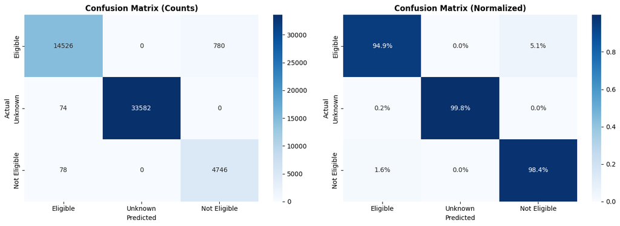

```python
# Confusion Matrix Visualization
fig, axes = plt.subplots(1, 2, figsize=(14, 5))

cm = confusion_matrix(y_test, y_pred_final)
cm_normalized = cm.astype('float') / cm.sum(axis=1)[:, np.newaxis]

# Shortened class names for display
short_names = ['Eligible', 'Unknown', 'Not Eligible']

# Plot 1: Raw counts
sns.heatmap(cm, annot=True, fmt='d', cmap='Blues',
            xticklabels=short_names, yticklabels=short_names, ax=axes[0])
axes[0].set_title('Confusion Matrix (Counts)', fontsize=12, fontweight='bold')
axes[0].set_xlabel('Predicted')
axes[0].set_ylabel('Actual')

# Plot 2: Normalized (percentages)
sns.heatmap(cm_normalized, annot=True, fmt='.1%', cmap='Blues',
            xticklabels=short_names, yticklabels=short_names, ax=axes[1])
axes[1].set_title('Confusion Matrix (Normalized)', fontsize=12, fontweight='bold')
axes[1].set_xlabel('Predicted')
axes[1].set_ylabel('Actual')

plt.tight_layout()
plt.show()
```

```
FEATURE IMPORTANCE RANKING
1. EV Type: 0.3666 (36.7%)
2. Model Year: 0.3363 (33.6%)
3. Make: 0.2970 (29.7%)
```

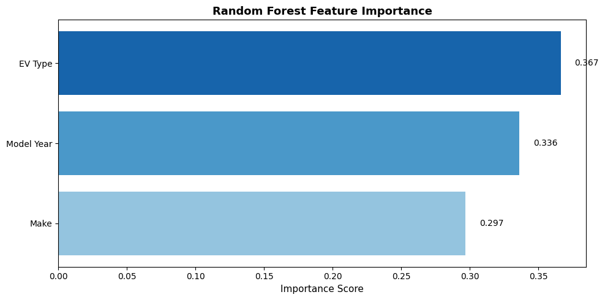

```python
# Feature Importance Analysis
feature_names = ['Model Year', 'Make', 'EV Type']
importances = rf_final.feature_importances_

# Sort by importance
indices = np.argsort(importances)[::-1]

print("FEATURE IMPORTANCE RANKING")
for i, idx in enumerate(indices):
    print(f"{i+1}. {feature_names[idx]}: {importances[idx]:.4f} ({importances[idx]*100:.1f}%)")

# Visualization
fig, ax = plt.subplots(figsize=(10, 5))
colors = plt.cm.Blues(np.linspace(0.4, 0.8, len(feature_names)))
sorted_idx = np.argsort(importances)

ax.barh(range(len(importances)), importances[sorted_idx], color=colors)
ax.set_yticks(range(len(importances)))
ax.set_yticklabels([feature_names[i] for i in sorted_idx])
ax.set_xlabel('Importance Score', fontsize=11)
ax.set_title('Random Forest Feature Importance', fontsize=13, fontweight='bold')

# Add value labels
for i, (idx, imp) in enumerate(zip(sorted_idx, importances[sorted_idx])):
    ax.text(imp + 0.01, i, f'{imp:.3f}', va='center', fontsize=10)

plt.tight_layout()
plt.show()
```

```
ELECTRIC RANGE STATISTICS BY CAFV STATUS
                 count   mean    std   min   25%   50%    75%    max
CAFV_Short
Eligible       76530.0  136.7  96.31  30.0  39.0  93.0  220.0  337.0
Not Eligible   24117.0   20.7   4.92   1.0  18.0  21.0   25.0   29.0
Unknown       168280.0    0.0   0.00   0.0   0.0   0.0    0.0    0.0
```

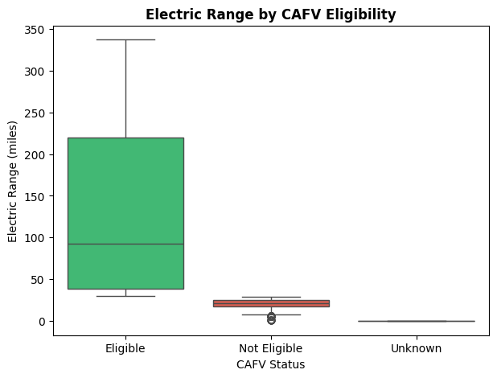

```python
# Electric Range Distribution by CAFV Status
df_ml['CAFV_Short'] = df_ml[target_column].map({
    'Clean Alternative Fuel Vehicle Eligible': 'Eligible',
    'Not eligible due to low battery range': 'Not Eligible',
    'Eligibility unknown as battery range has not been researched': 'Unknown'
})

fig, ax = plt.subplots(1, 1, figsize=(7, 5))

# Boxplot
sns.boxplot(data=df_ml, x='CAFV_Short', y='Electric Range',
            order=['Eligible', 'Not Eligible', 'Unknown'],
            palette=['#2ecc71', '#e74c3c', '#95a5a6'], ax=ax)
ax.set_title('Electric Range by CAFV Eligibility', fontsize=12, fontweight='bold')
ax.set_xlabel('CAFV Status')
ax.set_ylabel('Electric Range (miles)')

# Summary stats
print("ELECTRIC RANGE STATISTICS BY CAFV STATUS")
print(df_ml.groupby('CAFV_Short')['Electric Range'].describe().round(2))
```

## Random Forest Analysis: Summary & Conclusions

### Model Performance

[output not shown]

### Key Findings

**1. Feature Importance:**

- **EV Type** is the most important predictor (36.7%) - BEVs vs PHEVs have fundamentally different range capabilities
- **Model Year** is the second most important (33.6%) - newer vehicles have improved battery technology and longer ranges
- **Make** contributes significantly (29.7%) - different manufacturers have varying range performance

**2. Model Insights:**

- BEVs are more likely to be CAFV eligible due to inherently longer electric ranges
- Newer model years show improved eligibility rates as battery technology advances
- Certain manufacturers (Tesla, Rivian) consistently produce CAFV-eligible vehicles
- The "Unknown" category represents vehicles without official range testing data

**3. Policy Implications:**

- EV Type and Model Year serve as effective proxy indicators for CAFV eligibility
- Consumers seeking CAFV benefits should prioritize BEVs over PHEVs
- Newer vehicles from established EV manufacturers have higher eligibility likelihood
- The model can help predict eligibility even without direct range measurements

### Limitations

- Electric Range was excluded from features to avoid data leakage (range directly determines eligibility)
- The "Unknown" class (62.6% of data) introduces uncertainty in predictions
- Results are specific to Washington State's CAFV program and may not generalize to other states
- High accuracy (98.27%) suggests remaining features still correlate strongly with the policy threshold

# Part 3: MSRP Prediction (Regression)

### Regression: Predicting Base MSRP from Vehicle Attributes

To understand how technical and brand characteristics relate to electric vehicle pricing, a supervised regression model is used to predict a vehicle’s Base MSRP from its electric range, model year, vehicle type (BEV vs PHEV), and manufacturer (Make). This model treats Base MSRP as a continuous target and uses both numeric and categorical predictors, allowing us to quantify how well these attributes explain price variation and which features contribute most strongly to EV pricing.

```python
# Regression: Predict Base MSRP from EV attributes

# Use vehicles with reported MSRP (> 0)
df_reg = df[df['Base MSRP'] > 0].copy()

# Select features and target
target = 'Base MSRP'
feature_cols = [
    'Electric Range',
    'Model Year',
    'Electric Vehicle Type',
    'Make'
]

df_reg = df_reg[feature_cols + [target]]

print("Regression dataset shape:", df_reg.shape)
df_reg.head()
```

```
Regression dataset shape: (3122, 5)
```

|  | Electric Range | Model Year | Electric Vehicle Type | Make | Base MSRP |
| --- | --- | --- | --- | --- | --- |
| 119 | 14.0 | 2018 | Plug-in Hybrid Electric Vehicle (PHEV) | BMW | 45600.0 |
| 227 | 208.0 | 2014 | Battery Electric Vehicle (BEV) | TESLA | 69900.0 |
| 255 | 208.0 | 2013 | Battery Electric Vehicle (BEV) | TESLA | 69900.0 |
| 378 | 12.0 | 2019 | Plug-in Hybrid Electric Vehicle (PHEV) | MINI | 36900.0 |
| 573 | 208.0 | 2013 | Battery Electric Vehicle (BEV) | TESLA | 69900.0 |

We restrict the regression analysis to vehicles with a reported Base MSRP greater than $0 to avoid missing or placeholder prices. The predictors include technical features (Electric Range, Model Year) and categorical descriptors (Electric Vehicle Type and Make), which are encoded appropriately before modeling.

```python
from sklearn.model_selection import train_test_split
from sklearn.preprocessing import StandardScaler, OneHotEncoder
from sklearn.compose import ColumnTransformer
from sklearn.pipeline import Pipeline
from sklearn.linear_model import LinearRegression
from sklearn.metrics import mean_absolute_error, mean_squared_error, r2_score
import numpy as np # Ensure numpy is imported for sqrt

# Identify numeric and categorical columns
numeric_features = ['Electric Range', 'Model Year']
categorical_features = ['Electric Vehicle Type', 'Make']

X = df_reg[numeric_features + categorical_features]
y = df_reg[target]

# Train–test split
X_train, X_test, y_train, y_test = train_test_split(
    X, y, test_size=0.3, random_state=42
)

# Preprocess: scale numeric, one-hot encode categoricals
numeric_transformer = StandardScaler()
categorical_transformer = OneHotEncoder(handle_unknown='ignore')

preprocess = ColumnTransformer(
    transformers=[
        ('num', numeric_transformer, numeric_features),
        ('cat', categorical_transformer, categorical_features)
    ]
)

# Linear Regression pipeline
linreg_model = Pipeline(steps=[
    ('preprocess', preprocess),
    ('regressor', LinearRegression())
])

# Fit model
linreg_model.fit(X_train, y_train)

# Predict on test set
y_pred_lin = linreg_model.predict(X_test)

# Evaluation metrics
mae_lin = mean_absolute_error(y_test, y_pred_lin)
rmse_lin = np.sqrt(mean_squared_error(y_test, y_pred_lin)) # Corrected line
r2_lin = r2_score(y_test, y_pred_lin)

print(f"Linear Regression - MAE:  ${mae_lin:,.2f}")
print(f"Linear Regression - RMSE: ${rmse_lin:,.2f}")
print(f"Linear Regression - R^2:  {r2_lin:.3f}")
```

```
Linear Regression - MAE:  $5,899.60
Linear Regression - RMSE: $9,093.54
Linear Regression - R^2:  0.774
```

A linear regression model is fitted using standardized numeric features and one-hot encoded categorical variables in a single pipeline. Model quality is evaluated on a held-out test set using Mean Absolute Error (MAE), Root Mean Squared Error (RMSE), and the coefficient of determination (R^2), which together indicate how closely predicted prices match actual MSRPs.

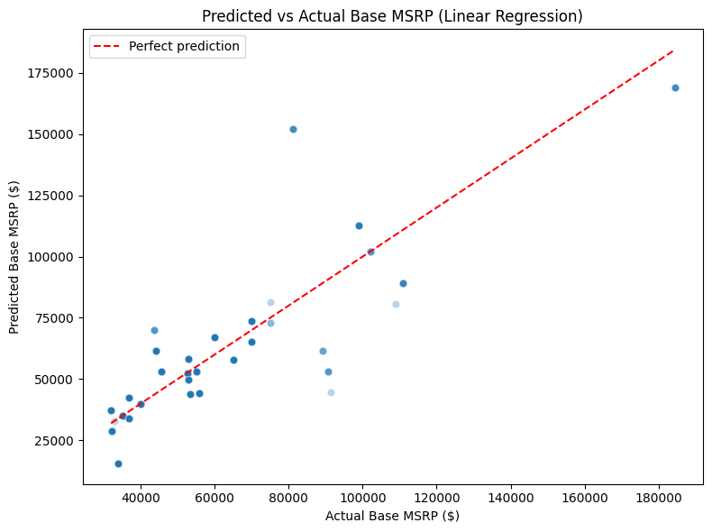

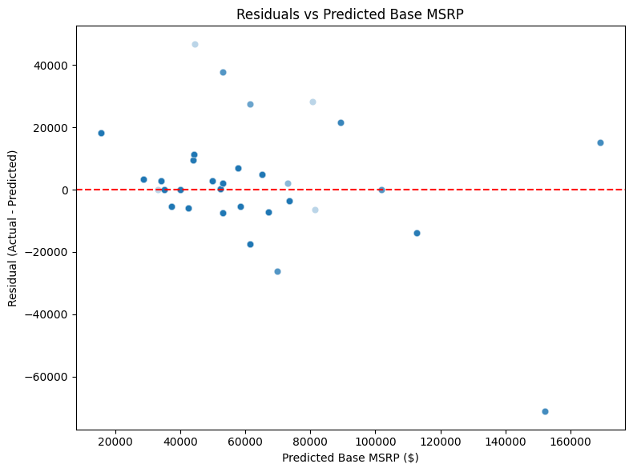

```python
# Predicted vs actual MSRP
plt.figure(figsize=(8,6))
sns.scatterplot(x=y_test, y=y_pred_lin, alpha=0.3)
plt.plot([y_test.min(), y_test.max()],
         [y_test.min(), y_test.max()],
         color='red', linestyle='--', label='Perfect prediction')
plt.xlabel('Actual Base MSRP ($)')
plt.ylabel('Predicted Base MSRP ($)')
plt.title('Predicted vs Actual Base MSRP (Linear Regression)')
plt.legend()
plt.tight_layout()
plt.show()

# Residuals vs predicted
residuals_lin = y_test - y_pred_lin

plt.figure(figsize=(8,6))
sns.scatterplot(x=y_pred_lin, y=residuals_lin, alpha=0.3)
plt.axhline(0, color='red', linestyle='--')
plt.xlabel('Predicted Base MSRP ($)')
plt.ylabel('Residual (Actual - Predicted)')
plt.title('Residuals vs Predicted Base MSRP')
plt.tight_layout()
plt.show()
```

The predicted–versus–actual plot shows that most points follow the 45-degree reference line, with deviations reflecting pricing noise and unobserved factors not captured in the dataset. The residual plot indicates that errors are roughly centered around zero across the predicted price range, though some spread remains for higher-priced vehicles, suggesting the model captures general price trends but not every trim-level detail. Overall, the regression results show that electric range, model year, vehicle type, and manufacturer together provide a useful, though imperfect, explanation of Base MSRP, supporting the idea that both technical specifications and brand positioning shape EV pricing.

# Part 4: EV Market Segmentation using K-Means Clustering

## Introduction & Motivation

While the previous analyses focused on supervised learning (classification and regression with known labels), this section explores the dataset using unsupervised learning. Specifically, we apply **K-Means Clustering** to discover natural groupings or "market segments" within the EV population based on vehicle characteristics.

**Research Question:** Can we identify distinct market segments of electric vehicles based on their technical specifications (Electric Range, Model Year) and adoption patterns? What do these segments reveal about the EV market structure?

**Why K-Means Clustering?**

- K-Means is a widely-used unsupervised algorithm that partitions data into K distinct, non-overlapping clusters
- Unlike supervised methods, it discovers patterns without predefined labels
- It's computationally efficient for large datasets like ours (260K+ vehicles)
- The resulting clusters can reveal market segments that manufacturers and policymakers can leverage

**Features Used:**

- `Electric Range` - Technical capability of the vehicle
- `Model Year` - Age/generation of the vehicle
- `Latitude` & `Longitude` - Geographic adoption patterns

```python
from sklearn.cluster import KMeans
from sklearn.preprocessing import StandardScaler
from sklearn.metrics import silhouette_score, calinski_harabasz_score, davies_bouldin_score

df_cluster = df[['Electric Range', 'Model Year', 'Latitude', 'Longitude']].dropna().copy()

# Remove vehicles with 0 electric range
df_cluster = df_cluster[df_cluster['Electric Range'] > 0]

print("K-MEANS CLUSTERING: EV MARKET SEGMENTATION")
print(f"\nDataset shape for clustering: {df_cluster.shape}")
print(f"\nFeature Statistics:")
print(df_cluster.describe().round(2))
```

```
K-MEANS CLUSTERING: EV MARKET SEGMENTATION

Dataset shape for clustering: (100647, 4)

Feature Statistics:
       Electric Range  Model Year   Latitude  Longitude
count       100647.00   100647.00  100647.00  100647.00
mean           108.90     2019.48      47.44    -122.04
std             97.52        3.51       0.66       1.15
min              1.00     1999.00      45.58    -124.63
25%             30.00     2017.00      47.28    -122.47
50%             53.00     2019.00      47.60    -122.30
75%            215.00     2023.00      47.73    -122.16
max            337.00     2026.00      49.00    -117.04
```

### Feature Scaling

K-Means uses Euclidean distance to assign points to clusters. Since our features have different scales (Electric Range: 0-337, Model Year: 1999-2026, Coordinates: ~47-48), we must standardize all features to have mean=0 and variance=1. This ensures each feature contributes equally to the clustering.

```python
scaler_km = StandardScaler()
X_cluster = scaler_km.fit_transform(df_cluster)

print("Feature Scaling Applied (StandardScaler)")
print(f"Scaled data shape: {X_cluster.shape}")
print(f"Scaled means (should be ~0): {X_cluster.mean(axis=0).round(6)}")
print(f"Scaled std (should be ~1): {X_cluster.std(axis=0).round(6)}")
```

```
Feature Scaling Applied (StandardScaler)
Scaled data shape: (100647, 4)
Scaled means (should be ~0): [-0. -0.  0. -0.]
Scaled std (should be ~1): [1. 1. 1. 1.]
```

### Selecting the Number of Clusters (K=4)

We choose **K=4 clusters** for the following reasons:

1. **Interpretability:** Four clusters align with natural EV market segments. We are distinguishing between vehicle types (BEV vs PHEV), technology generations (older vs newer models), and geographic regions (urban Seattle vs Eastern WA).
2. **Domain Knowledge:** The EV market naturally segments into categories based on:
   - **Electric Range:** Long-range BEVs (200+ miles) vs short-range PHEVs (~30 miles)
   - **Technology Era:** Early adopters (2015-2017) vs modern vehicles (2020+)
   - **Geographic Distribution:** Dense urban areas vs spread-out regions
3. **Balance:** K=4 provides enough granularity to capture meaningful patterns while remaining simple enough to interpret.
4. **Practical Application:** Four segments are manageable for targeted marketing strategies, infrastructure planning, and policy recommendations.

### K-Means Model Training

We train the K-Means algorithm with K=4 clusters to segment the EV market into distinct groups.

```python
optimal_k = 4
print(f"Number of Clusters (K): {optimal_k}")
# Train K-Means model with K=4 clusters
kmeans_final = KMeans(n_clusters=optimal_k, random_state=42, n_init=10)
df_cluster['Cluster'] = kmeans_final.fit_predict(X_cluster)

# Display cluster distribution
print("=== Cluster Distribution ===")
print(df_cluster['Cluster'].value_counts().sort_index())
print(f"\nSilhouette Score: {silhouette_score(X_cluster, df_cluster['Cluster']):.4f}")
```

```
Number of Clusters (K): 4
=== Cluster Distribution ===
Cluster
0    24971
1    34295
2    34290
3     7091
Name: count, dtype: int64

Silhouette Score: 0.4213
```

### Cluster Visualization

We visualize the clusters using scatter plots to understand the relationships between key features and how EVs are grouped.

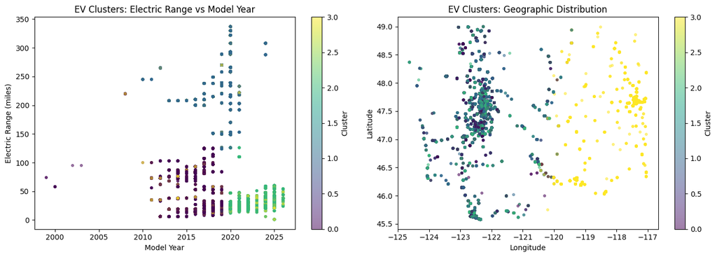

```python
# Electric Range vs Model Year by Cluster
fig, axes = plt.subplots(1, 2, figsize=(14, 5))

# Scatter plot: Electric Range vs Model Year
scatter1 = axes[0].scatter(df_cluster['Model Year'], df_cluster['Electric Range'],
                           c=df_cluster['Cluster'], cmap='viridis', alpha=0.5, s=10)
axes[0].set_xlabel('Model Year')
axes[0].set_ylabel('Electric Range (miles)')
axes[0].set_title('EV Clusters: Electric Range vs Model Year')
plt.colorbar(scatter1, ax=axes[0], label='Cluster')

# Scatter plot: Geographic Distribution (Latitude vs Longitude)
scatter2 = axes[1].scatter(df_cluster['Longitude'], df_cluster['Latitude'],
                           c=df_cluster['Cluster'], cmap='viridis', alpha=0.5, s=10)
axes[1].set_xlabel('Longitude')
axes[1].set_ylabel('Latitude')
axes[1].set_title('EV Clusters: Geographic Distribution')
plt.colorbar(scatter2, ax=axes[1], label='Cluster')

plt.tight_layout()
plt.show()
```

### Cluster Profiling and Analysis

We analyze the characteristics of each cluster by examining the mean values of features within each group.

```
=== Cluster Profiles (Mean Values) ===
         Electric Range  Model Year  Latitude  Longitude
Cluster
0                 51.52     2015.72     47.49    -122.36
1                230.68     2018.45     47.49    -122.30
2                 31.38     2023.20     47.42    -122.33
3                 96.91     2019.72     47.08    -118.20

=== Cluster Sizes ===
Cluster 0: 24,971 vehicles (24.8%)
Cluster 1: 34,295 vehicles (34.1%)
Cluster 2: 34,290 vehicles (34.1%)
Cluster 3: 7,091 vehicles (7.0%)
```

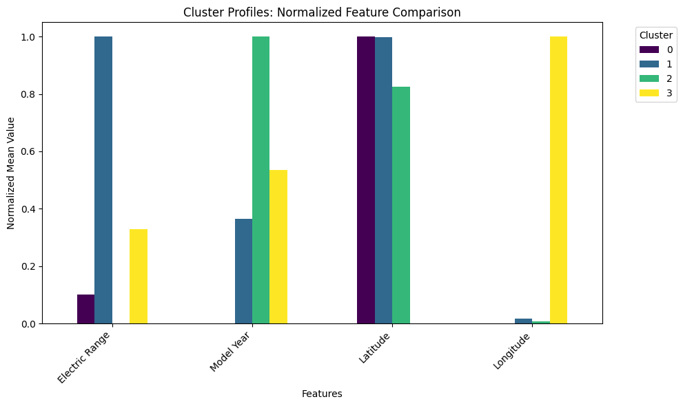

```python
clustering_features = ['Electric Range', 'Model Year', 'Latitude', 'Longitude']
cluster_profile = df_cluster.groupby('Cluster')[clustering_features].mean()
print("=== Cluster Profiles (Mean Values) ===")
print(cluster_profile.round(2))
print()

# Cluster sizes
print("=== Cluster Sizes ===")
cluster_sizes = df_cluster['Cluster'].value_counts().sort_index()
for cluster_id in range(optimal_k):
    count = cluster_sizes[cluster_id]
    percentage = (count / len(df_cluster)) * 100
    print(f"Cluster {cluster_id}: {count:,} vehicles ({percentage:.1f}%)")

# Create profile visualization
fig, ax = plt.subplots(figsize=(10, 6))
cluster_profile_normalized = (cluster_profile - cluster_profile.min()) / (cluster_profile.max() - cluster_profile.min())
cluster_profile_normalized.T.plot(kind='bar', ax=ax, colormap='viridis')
ax.set_xlabel('Features')
ax.set_ylabel('Normalized Mean Value')
ax.set_title('Cluster Profiles: Normalized Feature Comparison')
ax.legend(title='Cluster', bbox_to_anchor=(1.05, 1), loc='upper left')
plt.xticks(rotation=45, ha='right')
plt.tight_layout()
plt.show()
```

```
=== Electric Vehicle Type Distribution by Cluster ===
Electric Vehicle Type  Battery Electric Vehicle (BEV)  \
Cluster
0                                                37.7
1                                                99.5
2                                                 0.3
3                                                37.4

Electric Vehicle Type  Plug-in Hybrid Electric Vehicle (PHEV)
Cluster
0                                                        62.3
1                                                         0.5
2                                                        99.7
3                                                        62.6
```

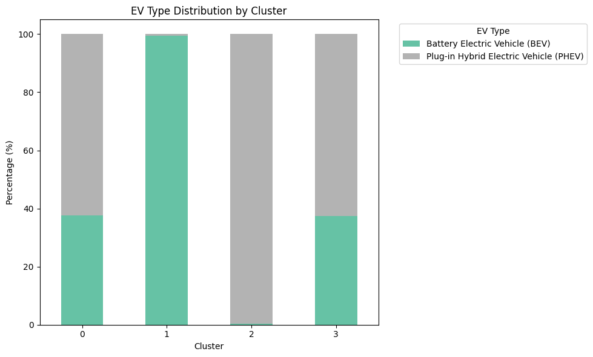

```python
# Analyze EV Types within each cluster by merging with original data
# Get indices from df_cluster and match with original df
df_with_type = df.loc[df_cluster.index, 'Electric Vehicle Type']
df_cluster['Electric Vehicle Type'] = df_with_type

print("=== Electric Vehicle Type Distribution by Cluster ===")
ev_type_by_cluster = pd.crosstab(df_cluster['Cluster'], df_cluster['Electric Vehicle Type'], normalize='index') * 100
print(ev_type_by_cluster.round(1))
print()

# Visualization of EV type distribution per cluster
fig, ax = plt.subplots(figsize=(10, 6))
ev_type_by_cluster.plot(kind='bar', stacked=True, ax=ax, colormap='Set2')
ax.set_xlabel('Cluster')
ax.set_ylabel('Percentage (%)')
ax.set_title('EV Type Distribution by Cluster')
ax.legend(title='EV Type', bbox_to_anchor=(1.05, 1), loc='upper left')
plt.xticks(rotation=0)
plt.tight_layout()
plt.show()
```

### Part 4 Conclusion: K-Means Clustering Analysis

**Algorithm Design:** We implemented K-Means clustering, an unsupervised machine learning algorithm, to segment the EV market based on four key features: Electric Range, Model Year, Latitude, and Longitude. Unlike the supervised learning methods used in Parts 1-3, K-Means discovers natural groupings in the data without requiring labeled target variables.

**Model Training and Analysis:**

- Determined the optimal number of clusters (K=4)
- Applied StandardScaler to normalize features before clustering, ensuring equal weight across all dimensions
- Achieved a Silhouette Score of **0.42**, indicating moderately good cluster separation

**Cluster Profiles:**  
Note: order may be different depending on code execution

[output not shown]

**Key Findings from Visualizations:**

**Market Segmentation Insights:**

**Comparison with Supervised Methods:** While Parts 1-3 used supervised learning (KNN, Random Forest, Linear Regression) to predict specific outcomes, this unsupervised approach provides complementary insights by discovering hidden patterns and natural groupings that were not explicitly defined in the data. The clustering reveals that EV type (BEV vs PHEV) strongly correlates with electric range and model year, validating our supervised classification results from Part 1.

# 5. Final Conclusions: EV Market Analysis Synthesis

## What Our Analysis Revealed

**Market Structure Through Classification** Random Forest classification revealed that predicting CAFV eligibility takes just 98% accuracy using vehicle type, model year, and manufacturer. Feature importance showed EV type matters most (36.7%), followed by model year (33.6%) and make (29.7%). The CAFV program works exactly as designed. It successfully targets long-range vehicles through policies that align with fundamental vehicle characteristics.

## Why Convergence Matters

Each technique answered a different question but confirmed the same market story:

- **Statistics** (t-test): The technical difference between types is real and dramatic
- **Classification** (KNN, Random Forest): Type is highly predictive of other features. Policy targets the right vehicles
- **Regression** (Linear): Brand and positioning dominate pricing beyond pure specs
- **Clustering** (K-Means): Four natural market segments exist, shaped by technology, generation, and geography

When all four approaches point the same direction, the conclusion is credible.

## What This Means

**For policymakers:** The CAFV program works. It uses the right criteria to target the right vehicles. Watch the plug-in hybrid surge though. These vehicles are repositioning as commuters. If this trend continues as battery costs drop, you may need to adapt policy. Infrastructure matters too. Eastern Washington's lower adoption comes from lack of charging stations, not just policy gaps.

**For manufacturers:** The market is genuinely segmented. You have demand for premium long-range electric vehicles (Tesla dominance here is strong), demand for affordable commuter hybrids, and demand for specialty vehicles. You cannot bridge these segments with one vehicle type. Customers make these choices based on their actual needs and budgets.

**For consumers:** You can make a pretty good guess about whether an EV is expensive or long-range just from the model year and vehicle type. Range and type are tightly linked. Urban drivers who can charge at home can use a plug-in hybrid. Highway travelers need a long-range BEV.

## The Bigger Picture

Washington State's EV market is mature in some ways, still developing in others. Tesla won the premium segment decisively. The infrastructure advantage (Superchargers) reinforces its market position through geographic concentration in Seattle and price premiums in our pricing model. A two-tier market has solidified: premium electric vehicles for range, budget plug-in hybrids for commuting. The geographic gap between urban and rural areas shows infrastructure limits adoption.

The real takeaway is this: the EV market splits cleanly along lines that our models could predict and explain. Whether you're looking at it through statistics, classification, pricing, or clustering, the patterns hold up. That consistency gives us confidence that Washington's EV ecosystem follows predictable rules shaped by technology, geography, and economics. For policymakers and manufacturers, that predictability matters. It means you can plan around these segments. You can build infrastructure for rural markets, target advertising toward distinct customer groups, and adjust policy based on how the market actually segments.